# **Libro de Tareas de Juan D. Gaviria S.**

#### *Ejercicio 4.*

Complete todo el análisis descriptivo de cada una de las variables junto con la interpretación de las gráficas correspondientes. Para esto, utilice diferentes gráficos y las medidas de variabilidad.

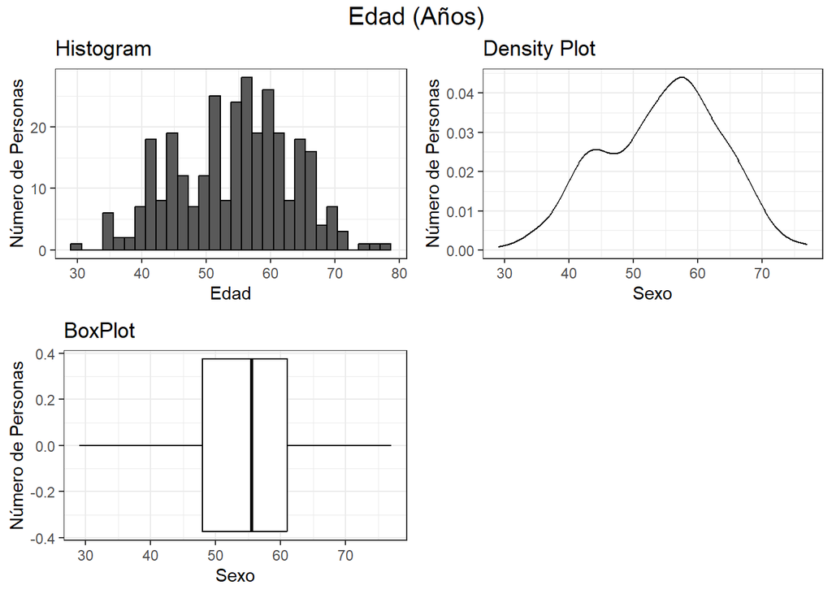

```r
sexh <- ggplot(dat.df, aes(x=age)) +
  geom_histogram(color="black") +
  labs(title="Histogram", x="Edad", y="Número de Personas") +
  scale_fill_brewer(palette="Set1") +  # Aplicar una paleta de colores de RColorBrewer
  theme_bw()

sexd <- ggplot(dat.df, aes(x=age)) +
  geom_density(color="black") +
  labs(title="Density Plot", x="Sexo", y="Número de Personas") +
  scale_fill_brewer(palette="Set1") +  # Aplicar una paleta de colores de RColorBrewer
  theme_bw()

sexb <- ggplot(dat.df, aes(x=age)) +
  geom_boxplot(color="black") +
  labs(title="BoxPlot", x="Sexo", y="Número de Personas") +
  scale_fill_brewer(palette="Set1") +  # Aplicar una paleta de colores de RColorBrewer
  theme_bw()

gridExtra::grid.arrange(
  sexh,
  sexd,
  sexb,
  ncol=2, nrow=2,
  top = textGrob("Edad (Años)",
                 gp=gpar(fontsize=15,
                         font=1)))
```

```r
summary(dat.df$age)
```

```
##    Min. 1st Qu.  Median    Mean 3rd Qu.    Max.
##   29.00   48.00   55.50   54.41   61.00   77.00
```

Como podemos ver, la variable edad en esta población tiene una distribución asimétrica con una desviación hacia la izquierda (negativa) donde la mediana es mayor que la media.

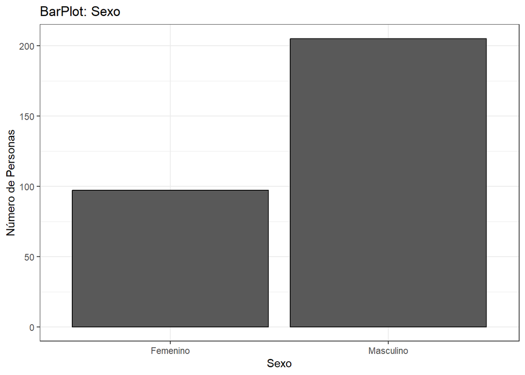

```r
ggplot(dat.df, aes(x=sex)) +
  geom_bar(color="black") +
  labs(title="BarPlot: Sexo", x="Sexo", y="Número de Personas") +
  scale_fill_brewer(palette="Set1") +  # Aplicar una paleta de colores de RColorBrewer
  theme_bw()
```

```r
summary(dat.df$sex)
```

```
##  Femenino Masculino
##        97       205
```

Como podemos ver, en la variable sexo, es másculino es quien presenta una mayor proporción con respecto al femenino.

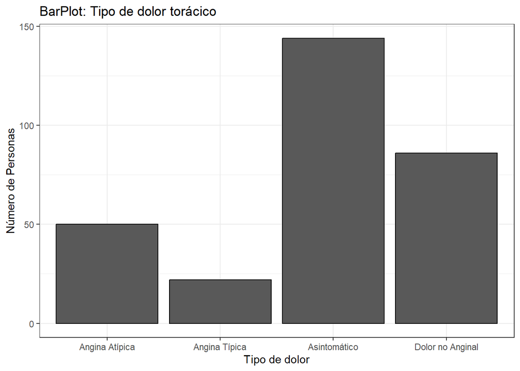

```r
ggplot(dat.df, aes(x=cp)) +
  geom_bar(color="black") +
  labs(title="BarPlot: Tipo de dolor torácico", x="Tipo de dolor", y="Número de Personas") +
  scale_fill_brewer(palette="Set1") +  # Aplicar una paleta de colores de RColorBrewer
  theme_bw()
```